# ex2

## 知識情報学 第2回演習サンプルプログラム ex2.ipynb

- Programmed by Wu Hongle, 監修 福井健一
- Last update: 2018/09/14
- Checked with Python 3.8.8, scikit-learn 1.0
- MIT License

## k近傍法による分類と識別面のプロット

```python
%matplotlib inline
from sklearn import datasets
import numpy as np
from matplotlib.colors import ListedColormap
import matplotlib.pyplot as plt
from sklearn.preprocessing import scale
from sklearn.model_selection import train_test_split
from sklearn.neighbors import KNeighborsClassifier
from sklearn.metrics import accuracy_score
```

### データの読み込みと標準化

- 【課題2】近傍数kを変更してみましょう．
- 【課題3】使用する特徴量(d1,d2)を変更してみましょう．

```python
# K近傍法の近傍数パラメータ k
neighbors = 5
# テストデータ分割のための乱数のシード（整数値）
random_seed = 1
#　テストデータの割合
test_proportion = 0.3
# Iris データセットをロード
iris = datasets.load_iris()
# 使用する特徴の次元を(Irisの場合は0,1,2,3から)2つ指定．d1とd2は異なる次元を指定すること
d1 = 0
d2 = 1
# d1,d2列目の特徴量を使用
X = iris.data[:, [d1, d2]]
# クラスラベルを取得
y = iris.target
# z標準化
X_std = scale(X)
```

### 課題1(a) データを学習データとテストデータに分割

- train_test_split()を使用し，変数test_proportionの割合をテストデータとし，変数random_seedを乱数生成器の状態に設定
- https://scikit-learn.org/stable/modules/generated/sklearn.model_selection.train_test_split.html

```python
X_train, X_test, y_train, y_test = train_test_split(X_std, y, test_size=test_proportion, random_state=random_seed)
```

### 課題1(b) クラスKNeighborsClassifierを使用してk近傍法のインスタンスを生成

- 近傍数kは上で指定したneighborsを使用

```python
knn = KNeighborsClassifier(n_neighbors=neighbors)
```

### k近傍法のモデルに学習データを適合

```python
knn.fit(X_train, y_train)
```

```
KNeighborsClassifier()
```

### 正答率の算出

```python
acc_train = accuracy_score(y_train, knn.predict(X_train))
acc_test  = accuracy_score(y_test, knn.predict(X_test))
print('k=%d, features=(%d,%d)' % (neighbors, d1, d2))
print('accuracy for training data: %f' % acc_train)
print('accuracy for test data: %f' % acc_test)
```

```
k=5, features=(0,1)
accuracy for training data: 0.847619
accuracy for test data: 0.688889
```

### 識別境界面をプロットする関数

各格子点に対してk近傍法で識別を行い，識別結果に応じて色を付けている

```python
def plot_decision_boundary(title=None):
    x1_min, x1_max = X_train[:, 0].min() - 0.5, X_train[:, 0].max() + 0.5
    x2_min, x2_max = X_train[:, 1].min() - 0.5, X_train[:, 1].max() + 0.5
    xx1, xx2 = np.meshgrid(np.arange(x1_min, x1_max, 0.02),
                           np.arange(x2_min, x2_max, 0.02))

    Z = knn.predict(np.array([xx1.ravel(), xx2.ravel()]).T)
    Z = Z.reshape(xx1.shape)

    markers = ('s', 'x', 'o', '^', 'v')
    colors = ('red', 'blue', 'lightgreen', 'gray', 'cyan')
    cmap = ListedColormap(colors[:len(np.unique(y))])

    plt.figure(figsize=(10,10))
    plt.subplot(211)

    plt.contourf(xx1, xx2, Z, alpha=0.5, cmap=cmap)
    plt.xlim(xx1.min(), xx1.max())
    plt.ylim(xx2.min(), xx2.max())

    for idx, cl in enumerate(np.unique(y_train)):
        plt.scatter(x=X_train[y_train == cl, 0], y=X_train[y_train == cl, 1],
                    alpha=0.8, c=colors[idx],
                    marker=markers[idx], label=cl)


    plt.xlabel('sepal length [standardized]')
    plt.ylabel('sepal width [standardized]')
    plt.title('train_data')

    plt.subplot(212)

    plt.contourf(xx1, xx2, Z, alpha=0.5, cmap=cmap)
    plt.xlim(xx1.min(), xx1.max())
    plt.ylim(xx2.min(), xx2.max())

    for idx, cl in enumerate(np.unique(y_test)):
        plt.scatter(x=X_test[y_test == cl, 0], y=X_test[y_test == cl, 1],
                    alpha=0.8, c=colors[idx],
                    marker=markers[idx], label=cl)


    plt.xlabel('sepal length [standardized]')
    plt.ylabel('sepal width [standardized]')
    plt.title('test_data')

    plt.suptitle(title)
    plt.show()
```

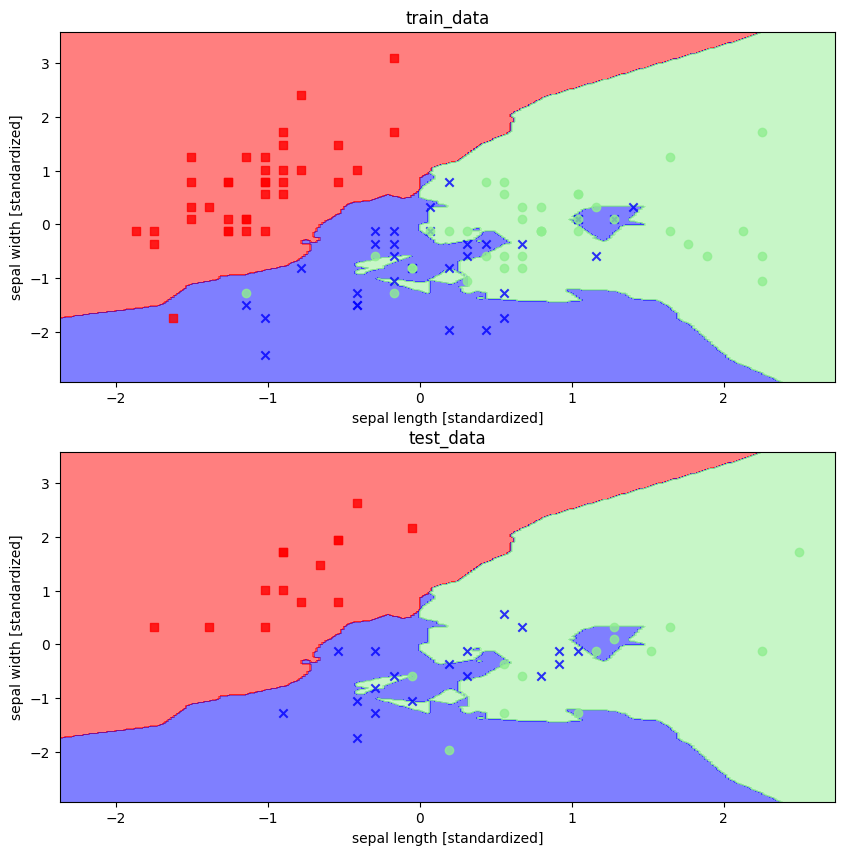

```python
plot_decision_boundary()
```

## 課題2-2 近傍数kの影響について，識別境界および正解率 （Accuracy）の観点で考察しなさい

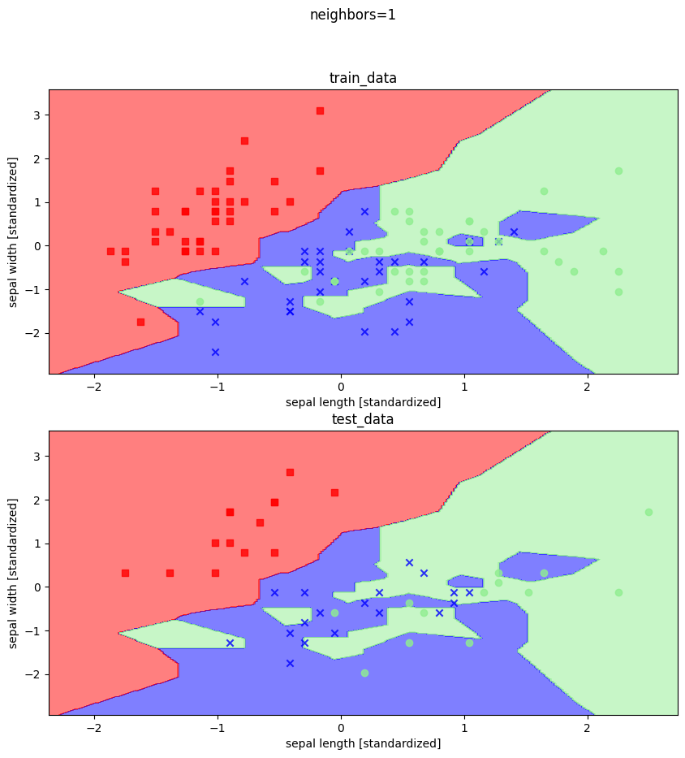

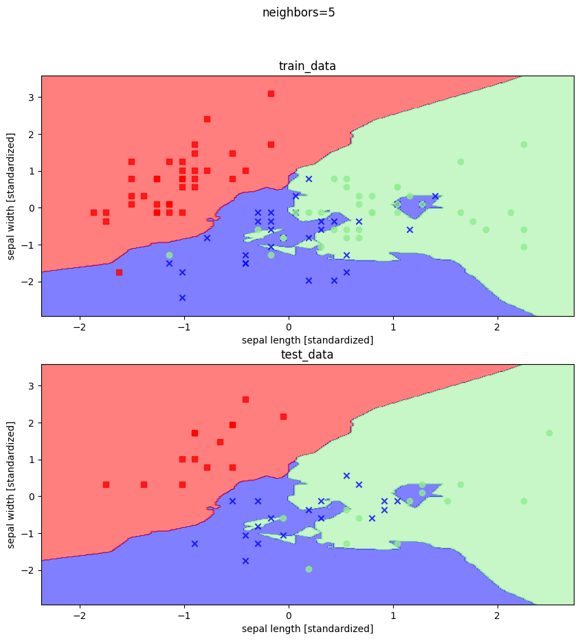

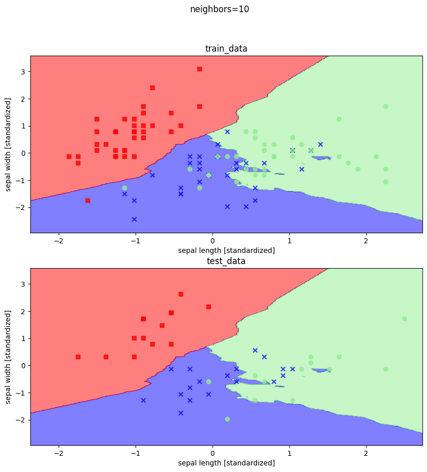

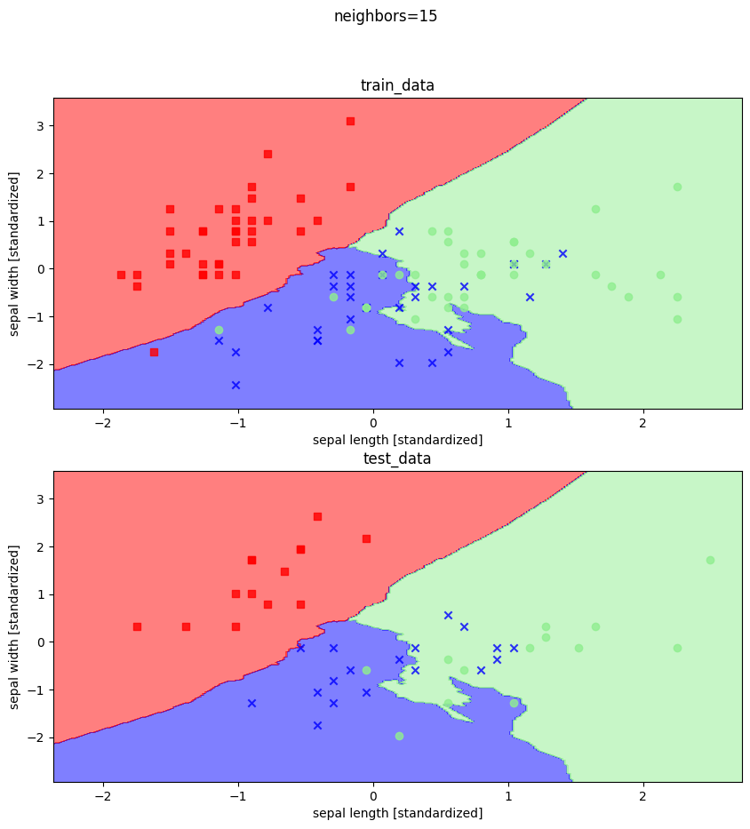

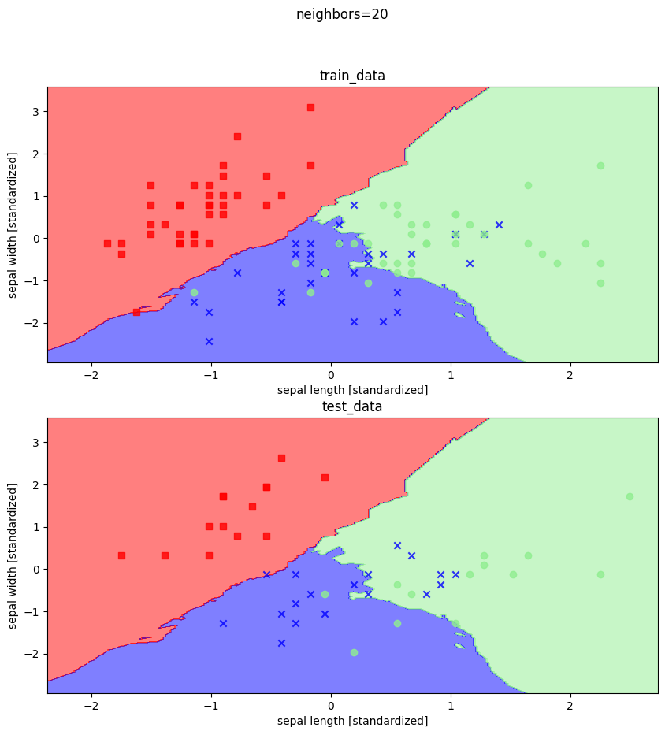

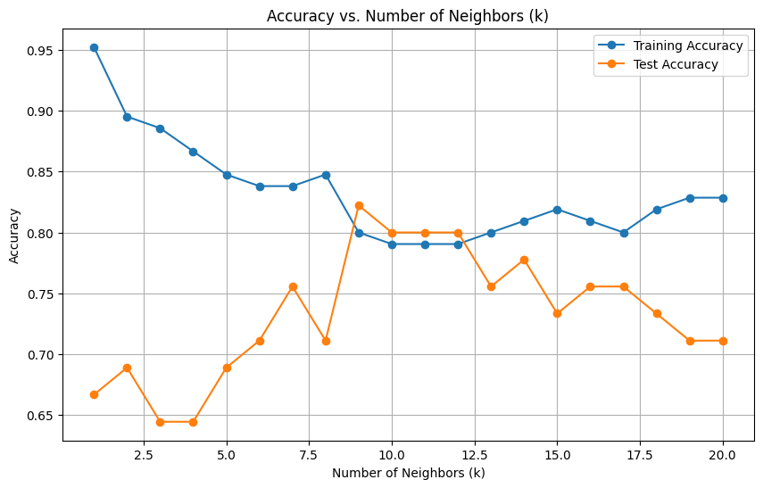

```python
# 1から20までのkの値を試す
k_values = range(1, 21)

# 正解率を保存するリスト
train_accuracies = []
test_accuracies = []

for k in k_values:
    knn = KNeighborsClassifier(n_neighbors=k)
    knn.fit(X_train, y_train)

    # 訓練データとテストデータでの正解率を計算
    acc_train = accuracy_score(y_train, knn.predict(X_train))
    acc_test  = accuracy_score(y_test, knn.predict(X_test))

    train_accuracies.append(acc_train)
    test_accuracies.append(acc_test)
    if k in [1,5,10,15,20]:
        plot_decision_boundary(f'neighbors={k}')

plt.figure(figsize=(10, 6))
plt.plot(k_values, train_accuracies, label='Training Accuracy', marker='o')
plt.plot(k_values, test_accuracies, label='Test Accuracy', marker='o')
plt.title('Accuracy vs. Number of Neighbors (k)')
plt.xlabel('Number of Neighbors (k)')
plt.ylabel('Accuracy')
plt.legend()
plt.grid(True)
plt.show()
```

### 考察

上の図は、近傍数1,5,10,15,20のときの識別境界の図と、1~20の近傍数の時の訓練、テストデータの正解率である。  
近傍数が小さい場合、モデルは訓練データに過剰適合し複雑な識別境界を持ったため、テストデータでの正解率は低くなったと考えられる。  
一方、近傍数が大きい場合、モデルは訓練データに対して一般化されたため、識別境界は滑らかになり、正解率が低下したと考えられる。

## 課題2-3. 使用する特徴量を変えて，特徴量と識別境界や正解率との関係を考察しなさい．

```python
# K近傍法の近傍数パラメータ k
neighbors = 10 # 課題2-2より、近傍数10を使用

# テストデータ分割のための乱数のシード（整数値）
random_seed = 1
#　テストデータの割合
test_proportion = 0.3
# Iris データセットをロード
iris = datasets.load_iris()

# 使用したパラメータを保存するリスト
used_param = []
# 正解率を保存するリスト
train_accuracies = []
test_accuracies = []


for d1 in range(0,4):
    for d2 in range(d1+1,4):
        used_param.append(iris.feature_names[d1]+"\n"+iris.feature_names[d2])

        # d1,d2列目の特徴量を使用
        X = iris.data[:, [d1, d2]]
        y = iris.target
        X_std = scale(X)

        X_train, X_test, y_train, y_test = train_test_split(X_std, y, test_size=test_proportion, random_state=random_seed)

        knn = KNeighborsClassifier(n_neighbors=neighbors)
        knn.fit(X_train, y_train)

        # 訓練データとテストデータでの正解率を計算
        acc_train = accuracy_score(y_train, knn.predict(X_train))
        acc_test  = accuracy_score(y_test, knn.predict(X_test))

        train_accuracies.append(acc_train)
        test_accuracies.append(acc_test)
```

[figure not shown]

```python
plt.figure(figsize=(10, 6))
plt.plot(used_param, train_accuracies, 'o', label='Training Accuracy')
plt.plot(used_param, test_accuracies, 'o', label='Test Accuracy')
plt.title('Accuracy vs. Number of Neighbors (k)')
plt.xlabel('Number of Neighbors (k)')
plt.ylabel('Accuracy')
plt.legend()
plt.grid(True)
plt.show()
```